# Homework 01

Joe Dickerson

2025-01-27

```r
## Packages
library(faraway)
library(tidyverse)
library(MASS)
library(vcdExtra)
library(glmtoolbox)
library(pROC)
```

1. The plot is not illustrative in a helpful way. We have no conception of how the data is distributed because the points are all stacked on top of one another.

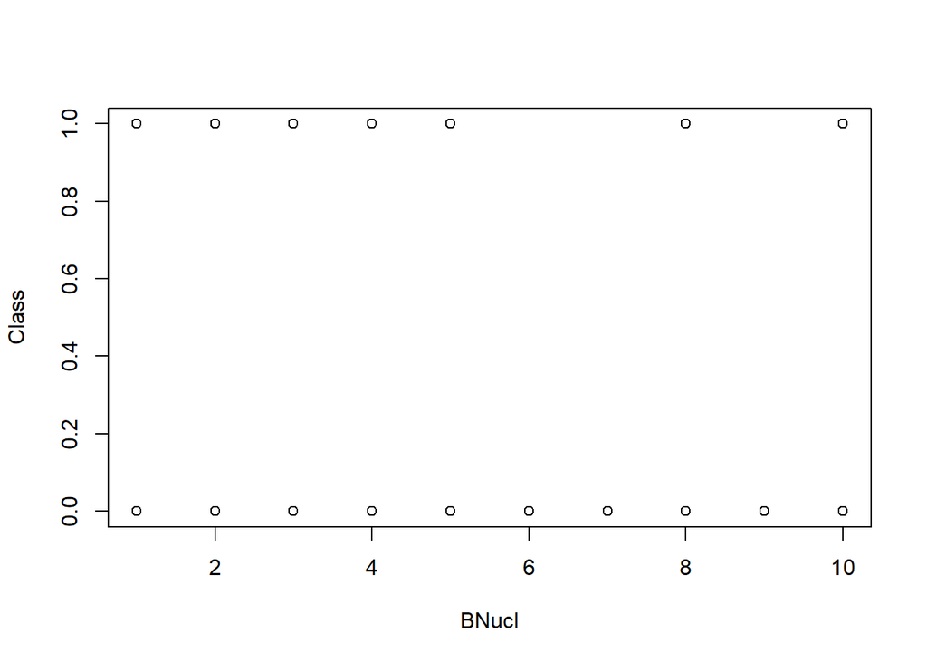

```r
data(wbca)

plot(Class ~ BNucl, wbca)
```

2. We notice that a high BNucl appears to have some sort of relationship to whether a tumor is malignant or benign. We see here that higher a Bnucl might make it more probable for a tumor to be malignant.

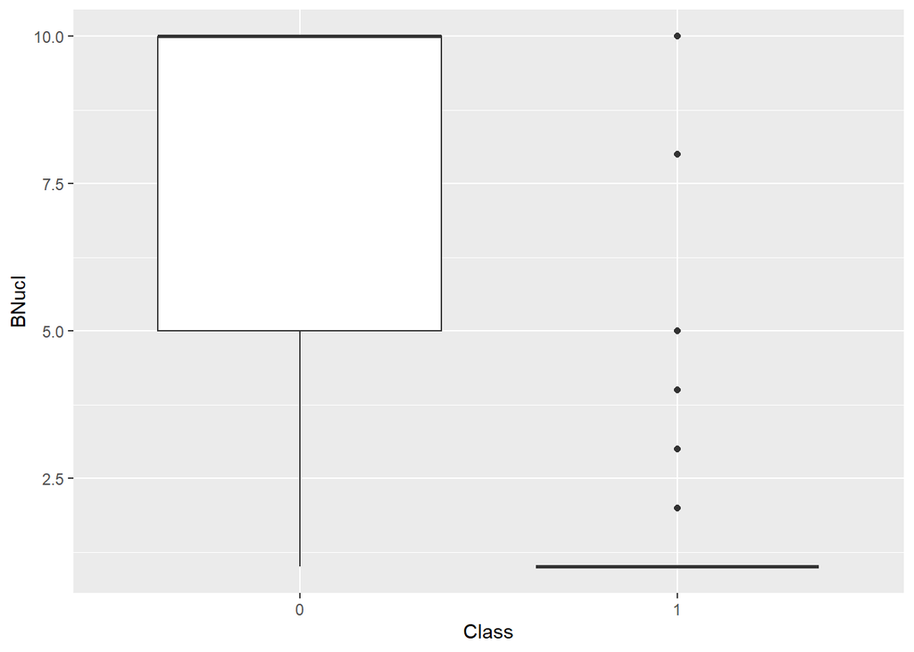

```r
wbca %>%
  ggplot(aes(x = factor(Class), y = BNucl)) +
  geom_boxplot() +
  labs(x = "Class", y = "BNucl")
```

3. This plot seems to indicate that a small BNucl measurement is more likely to have a benign tumor, while a high BNucl measurement is more likely to have an instance of a malignant tumor.

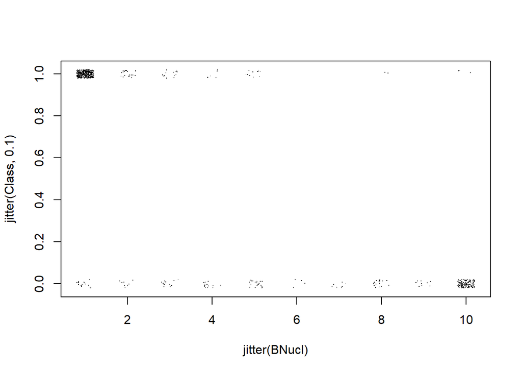

```r
plot(jitter(Class, 0.1) ~ jitter(BNucl), wbca, pch = ".")
```

4. Similarly to the previous visualizations, we see higher instances of malignant tumors with high BNucl, and higher instances of benign tumors with low BNucl.

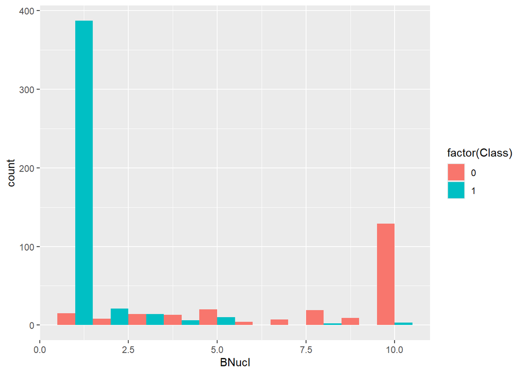

```r
wbca %>%
  ggplot(aes(x = BNucl, fill = factor(Class), group = factor(Class))) +
  geom_histogram(position = "dodge", binwidth = 1)
```

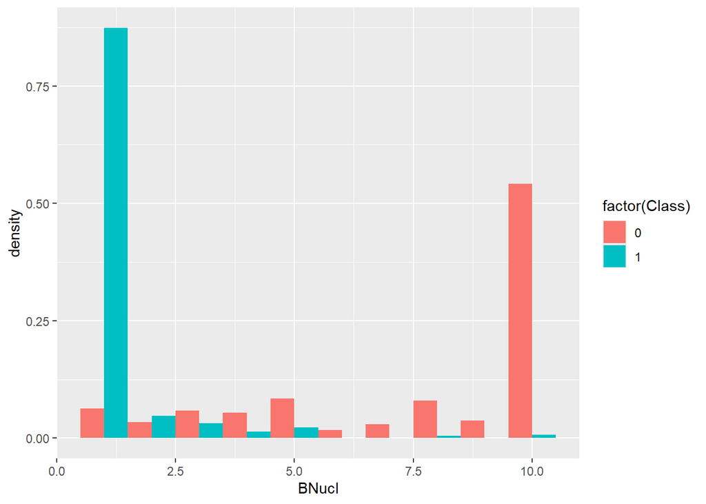

```r
wbca %>%
  ggplot(aes(x = BNucl, fill = factor(Class), group = factor(Class))) +
  geom_histogram(position = "dodge", binwidth = 1, aes(y=..density..))
```

2. In the first graph, it appears that higher clump thickness will relate to higher bare nuclei, while lower clump thickness indicates lower bare nuclei. In the second graph, we see similar distribution, and that higher clump thickness may contribute to a tumor being malignant, while lower clump thickness might contribute to a tumor being benign.

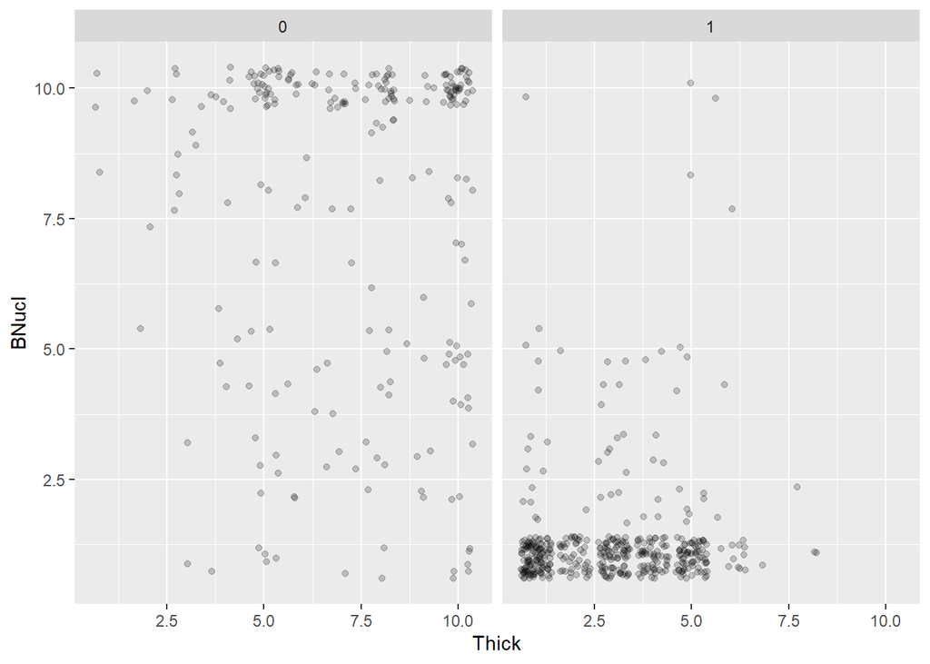

```r
wbca %>%
  ggplot(aes(x = Thick, y = BNucl)) +
  geom_point(alpha=0.2, position = position_jitter()) +
  facet_grid( ~ Class)
```

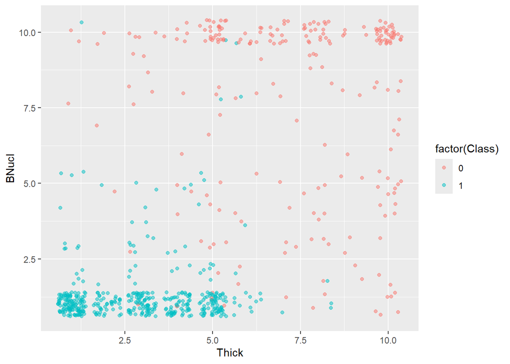

```r
wbca %>%
  ggplot(aes(x = Thick, y = BNucl, color = factor(Class),
             group = factor(Class))) +
  geom_point(alpha = 0.5, position = position_jitter())
```

3. We have a residual deviance of 89.464 on 671 degrees of freedom. However, for binary data the residual deviance should not be used for determining goodness of fit.

```r
glmod <- glm(Class ~ ., family = binomial, wbca)

summary(glmod)
```

```
##
## Call:
## glm(formula = Class ~ ., family = binomial, data = wbca)
##
## Coefficients:
##             Estimate Std. Error z value Pr(>|z|)
## (Intercept) 11.16678    1.41491   7.892 2.97e-15 ***
## Adhes       -0.39681    0.13384  -2.965  0.00303 **
## BNucl       -0.41478    0.10230  -4.055 5.02e-05 ***
## Chrom       -0.56456    0.18728  -3.014  0.00257 **
## Epith       -0.06440    0.16595  -0.388  0.69795
## Mitos       -0.65713    0.36764  -1.787  0.07387 .
## NNucl       -0.28659    0.12620  -2.271  0.02315 *
## Thick       -0.62675    0.15890  -3.944 8.01e-05 ***
## UShap       -0.28011    0.25235  -1.110  0.26699
## USize        0.05718    0.23271   0.246  0.80589
## ---
## Signif. codes:  0 '***' 0.001 '**' 0.01 '*' 0.05 '.' 0.1 ' ' 1
##
## (Dispersion parameter for binomial family taken to be 1)
##
##     Null deviance: 881.388  on 680  degrees of freedom
## Residual deviance:  89.464  on 671  degrees of freedom
## AIC: 109.46
##
## Number of Fisher Scoring iterations: 8
```

4. It appears a model excluding Epith (epithelial cell size) and USize (cell size uniformity) contains the best subset of variables. However, performing a Hosmer-Lemeshow goodness-of-fit test returns a p-value of 0.8125. Discussed in the lecture, the Hosmer-Lemeshow test might not be the most reliable.

```r
step(glmod)
```

```
## Start:  AIC=109.46
## Class ~ Adhes + BNucl + Chrom + Epith + Mitos + NNucl + Thick +
##     UShap + USize
##
##         Df Deviance    AIC
## - USize  1   89.523 107.52
## - Epith  1   89.613 107.61
## - UShap  1   90.627 108.63
## <none>       89.464 109.46
## - Mitos  1   93.551 111.55
## - NNucl  1   95.204 113.20
## - Adhes  1   98.844 116.84
## - Chrom  1   99.841 117.84
## - BNucl  1  109.000 127.00
## - Thick  1  110.239 128.24
##
## Step:  AIC=107.52
## Class ~ Adhes + BNucl + Chrom + Epith + Mitos + NNucl + Thick +
##     UShap
##
##         Df Deviance    AIC
## - Epith  1   89.662 105.66
## - UShap  1   91.355 107.36
## <none>       89.523 107.52
## - Mitos  1   93.552 109.55
## - NNucl  1   95.231 111.23
## - Adhes  1   99.042 115.04
## - Chrom  1  100.153 116.15
## - BNucl  1  109.064 125.06
## - Thick  1  110.465 126.47
##
## Step:  AIC=105.66
## Class ~ Adhes + BNucl + Chrom + Mitos + NNucl + Thick + UShap
##
##         Df Deviance    AIC
## <none>       89.662 105.66
## - UShap  1   91.884 105.88
## - Mitos  1   93.714 107.71
## - NNucl  1   95.853 109.85
## - Adhes  1  100.126 114.13
## - Chrom  1  100.844 114.84
## - BNucl  1  109.762 123.76
## - Thick  1  110.632 124.63
```

```
##
## Call:  glm(formula = Class ~ Adhes + BNucl + Chrom + Mitos + NNucl +
##     Thick + UShap, family = binomial, data = wbca)
##
## Coefficients:
## (Intercept)        Adhes        BNucl        Chrom        Mitos        NNucl
##     11.0333      -0.3984      -0.4192      -0.5679      -0.6456      -0.2915
##       Thick        UShap
##     -0.6216      -0.2541
##
## Degrees of Freedom: 680 Total (i.e. Null);  673 Residual
## Null Deviance:       881.4
## Residual Deviance: 89.66     AIC: 105.7
```

```r
subsetmodel <- step(glmod)
```

```
## Start:  AIC=109.46
## Class ~ Adhes + BNucl + Chrom + Epith + Mitos + NNucl + Thick +
##     UShap + USize
##
##         Df Deviance    AIC
## - USize  1   89.523 107.52
## - Epith  1   89.613 107.61
## - UShap  1   90.627 108.63
## <none>       89.464 109.46
## - Mitos  1   93.551 111.55
## - NNucl  1   95.204 113.20
## - Adhes  1   98.844 116.84
## - Chrom  1   99.841 117.84
## - BNucl  1  109.000 127.00
## - Thick  1  110.239 128.24
##
## Step:  AIC=107.52
## Class ~ Adhes + BNucl + Chrom + Epith + Mitos + NNucl + Thick +
##     UShap
##
##         Df Deviance    AIC
## - Epith  1   89.662 105.66
## - UShap  1   91.355 107.36
## <none>       89.523 107.52
## - Mitos  1   93.552 109.55
## - NNucl  1   95.231 111.23
## - Adhes  1   99.042 115.04
## - Chrom  1  100.153 116.15
## - BNucl  1  109.064 125.06
## - Thick  1  110.465 126.47
##
## Step:  AIC=105.66
## Class ~ Adhes + BNucl + Chrom + Mitos + NNucl + Thick + UShap
##
##         Df Deviance    AIC
## <none>       89.662 105.66
## - UShap  1   91.884 105.88
## - Mitos  1   93.714 107.71
## - NNucl  1   95.853 109.85
## - Adhes  1  100.126 114.13
## - Chrom  1  100.844 114.84
## - BNucl  1  109.762 123.76
## - Thick  1  110.632 124.63
```

```r
summary(subsetmodel)
```

```
##
## Call:
## glm(formula = Class ~ Adhes + BNucl + Chrom + Mitos + NNucl +
##     Thick + UShap, family = binomial, data = wbca)
##
## Coefficients:
##             Estimate Std. Error z value Pr(>|z|)
## (Intercept)  11.0333     1.3632   8.094 5.79e-16 ***
## Adhes        -0.3984     0.1294  -3.080  0.00207 **
## BNucl        -0.4192     0.1020  -4.111 3.93e-05 ***
## Chrom        -0.5679     0.1840  -3.085  0.00203 **
## Mitos        -0.6456     0.3634  -1.777  0.07561 .
## NNucl        -0.2915     0.1236  -2.358  0.01837 *
## Thick        -0.6216     0.1579  -3.937 8.27e-05 ***
## UShap        -0.2541     0.1785  -1.423  0.15461
## ---
## Signif. codes:  0 '***' 0.001 '**' 0.01 '*' 0.05 '.' 0.1 ' ' 1
##
## (Dispersion parameter for binomial family taken to be 1)
##
##     Null deviance: 881.388  on 680  degrees of freedom
## Residual deviance:  89.662  on 673  degrees of freedom
## AIC: 105.66
##
## Number of Fisher Scoring iterations: 8
```

```r
hltest(subsetmodel)
```

```
##
##    The Hosmer-Lemeshow goodness-of-fit test
##
##  Group Size Observed    Expected
##      1   68        0  0.00107663
##      2   68        0  0.03558844
##      3   68        2  0.87081061
##      4   68       32 35.35122920
##      5   67       67 65.74084658
##      6   64       64 63.51813730
##      7   68       68 67.74134804
##      8   68       68 67.85992638
##      9   74       74 73.91777226
##     10   68       68 67.96326454
##
##          Statistic =  4.46945
## degrees of freedom =  8
##            p-value =  0.81248
```

```r
table(wbca$Class, ifelse(predict(subsetmodel, type = "response") < 0.5, "no", "yes"))
```

```
##
##      no yes
##   0 227  11
##   1   9 434
```

```r
table(wbca$Class, ifelse(predict(subsetmodel, type = "response") < 0.9, "no", "yes"))
```

```
##
##      no yes
##   0 237   1
##   1  16 427
```

7. We find a very favorable ROC plot with an area of 0.9974 under the curve, which indicates a good fit. The area under curve is useful because it can be used to measure the efficacy of different models.

```r
predprob <- predict(subsetmodel, type = "response")

wbcam <- mutate(wbca, residuals = residuals(subsetmodel), linpred = predict(subsetmodel))

mod_roc = roc(wbca$Class, predprob)
```

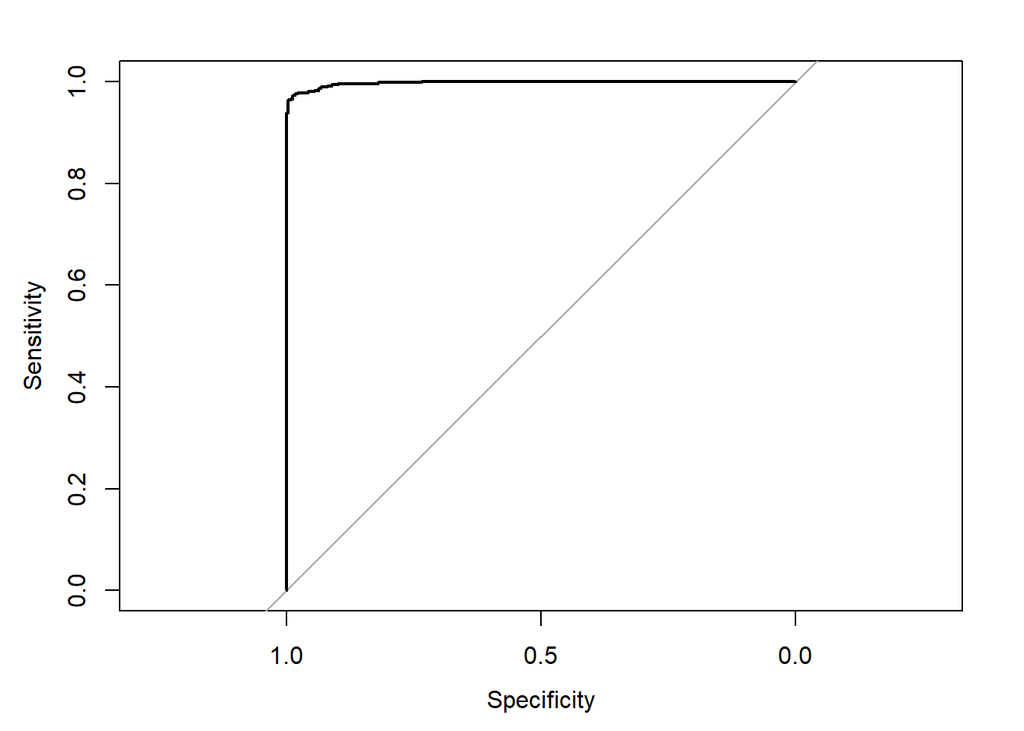

```r
plot(mod_roc)
```

```r
auc(mod_roc)
```

```
## Area under the curve: 0.9974
```

8. Our training data determines the best model to exclude Epith, UShap, and USize. We see similar results of predictive performance compared to the full model.

```r
set.seed(123)

sequence <- seq(1, 681, by = 3)

wbcaTest <- wbca[sequence,]
wbcaTrain <- wbca[-sequence,]

## Determining model

glmTrain <- glm(Class ~ ., family = binomial, wbcaTrain)

step(glmTrain)
```

```
## Start:  AIC=73.31
## Class ~ Adhes + BNucl + Chrom + Epith + Mitos + NNucl + Thick +
##     UShap + USize
##
##         Df Deviance    AIC
## - Epith  1   53.370 71.370
## - UShap  1   53.408 71.408
## - USize  1   53.733 71.733
## <none>       53.308 73.308
## - Adhes  1   57.204 75.204
## - NNucl  1   57.326 75.326
## - Mitos  1   57.545 75.545
## - Chrom  1   62.154 80.154
## - BNucl  1   62.955 80.955
## - Thick  1   71.364 89.364
##
## Step:  AIC=71.37
## Class ~ Adhes + BNucl + Chrom + Mitos + NNucl + Thick + UShap +
##     USize
##
##         Df Deviance    AIC
## - UShap  1   53.450 69.450
## - USize  1   53.818 69.818
## <none>       53.370 71.370
## - Adhes  1   57.322 73.322
## - NNucl  1   57.362 73.362
## - Mitos  1   57.574 73.574
## - Chrom  1   62.339 78.339
## - BNucl  1   63.531 79.531
## - Thick  1   71.989 87.989
##
## Step:  AIC=69.45
## Class ~ Adhes + BNucl + Chrom + Mitos + NNucl + Thick + USize
##
##         Df Deviance    AIC
## - USize  1   53.988 67.988
## <none>       53.450 69.450
## - NNucl  1   57.433 71.433
## - Adhes  1   57.437 71.437
## - Mitos  1   57.612 71.612
## - Chrom  1   62.375 76.375
## - BNucl  1   64.240 78.240
## - Thick  1   72.293 86.293
##
## Step:  AIC=67.99
## Class ~ Adhes + BNucl + Chrom + Mitos + NNucl + Thick
```

```
##         Df Deviance    AIC
## <none>       53.988 67.988
## - Mitos  1   58.479 70.479
## - NNucl  1   59.190 71.190
## - Adhes  1   59.915 71.915
## - BNucl  1   68.348 80.348
## - Chrom  1   70.900 82.900
## - Thick  1   76.052 88.052
```

```
##
## Call:  glm(formula = Class ~ Adhes + BNucl + Chrom + Mitos + NNucl +
##     Thick, family = binomial, data = wbcaTrain)
##
## Coefficients:
## (Intercept)        Adhes        BNucl        Chrom        Mitos        NNucl
##     12.6320      -0.3568      -0.4452      -0.8138      -0.9295      -0.3313
##       Thick
##     -0.8747
##
## Degrees of Freedom: 453 Total (i.e. Null);  447 Residual
## Null Deviance:       582.9
## Residual Deviance: 53.99     AIC: 67.99
```

```r
Trainmodel <- step(glmTrain)
```

```
## Start:  AIC=73.31
## Class ~ Adhes + BNucl + Chrom + Epith + Mitos + NNucl + Thick +
##     UShap + USize
##
##         Df Deviance    AIC
## - Epith  1   53.370 71.370
## - UShap  1   53.408 71.408
## - USize  1   53.733 71.733
## <none>       53.308 73.308
## - Adhes  1   57.204 75.204
## - NNucl  1   57.326 75.326
## - Mitos  1   57.545 75.545
## - Chrom  1   62.154 80.154
## - BNucl  1   62.955 80.955
## - Thick  1   71.364 89.364
##
## Step:  AIC=71.37
## Class ~ Adhes + BNucl + Chrom + Mitos + NNucl + Thick + UShap +
##     USize
##
##         Df Deviance    AIC
## - UShap  1   53.450 69.450
## - USize  1   53.818 69.818
## <none>       53.370 71.370
## - Adhes  1   57.322 73.322
## - NNucl  1   57.362 73.362
## - Mitos  1   57.574 73.574
## - Chrom  1   62.339 78.339
## - BNucl  1   63.531 79.531
## - Thick  1   71.989 87.989
##
## Step:  AIC=69.45
## Class ~ Adhes + BNucl + Chrom + Mitos + NNucl + Thick + USize
##
##         Df Deviance    AIC
## - USize  1   53.988 67.988
## <none>       53.450 69.450
## - NNucl  1   57.433 71.433
## - Adhes  1   57.437 71.437
## - Mitos  1   57.612 71.612
## - Chrom  1   62.375 76.375
## - BNucl  1   64.240 78.240
## - Thick  1   72.293 86.293
##
## Step:  AIC=67.99
## Class ~ Adhes + BNucl + Chrom + Mitos + NNucl + Thick
```

```
##         Df Deviance    AIC
## <none>       53.988 67.988
## - Mitos  1   58.479 70.479
## - NNucl  1   59.190 71.190
## - Adhes  1   59.915 71.915
## - BNucl  1   68.348 80.348
## - Chrom  1   70.900 82.900
## - Thick  1   76.052 88.052
```

```r
summary(Trainmodel)
```

```
##
## Call:
## glm(formula = Class ~ Adhes + BNucl + Chrom + Mitos + NNucl +
##     Thick, family = binomial, data = wbcaTrain)
##
## Coefficients:
##             Estimate Std. Error z value Pr(>|z|)
## (Intercept)  12.6320     2.1334   5.921  3.2e-09 ***
## Adhes        -0.3568     0.1513  -2.358 0.018359 *
## BNucl        -0.4452     0.1270  -3.505 0.000457 ***
## Chrom        -0.8138     0.2768  -2.940 0.003283 **
## Mitos        -0.9295     0.3839  -2.421 0.015464 *
## NNucl        -0.3313     0.1538  -2.153 0.031284 *
## Thick        -0.8747     0.2613  -3.348 0.000815 ***
## ---
## Signif. codes:  0 '***' 0.001 '**' 0.01 '*' 0.05 '.' 0.1 ' ' 1
##
## (Dispersion parameter for binomial family taken to be 1)
##
##     Null deviance: 582.905  on 453  degrees of freedom
## Residual deviance:  53.988  on 447  degrees of freedom
## AIC: 67.988
##
## Number of Fisher Scoring iterations: 9
```

```r
## Predictive Performance

predTest <- predict(Trainmodel, type="response", newdata = wbcaTest)

table(wbcaTest$Class, ifelse(predTest < 0.5, "no", "yes"))
```

```
##
##      no yes
##   0  79   4
##   1   5 139
```

```r
table(wbcaTest$Class, ifelse(predTest < 0.9, "no", "yes"))
```

```
##
##      no yes
##   0  82   1
##   1  11 133
```